# 비닝(Binning)

2021-02-06T17:09:12+08:00

## 다룰 이야기

연속형 변수가 범주화되면 디테일한 데이터의 정보가 사라진다. 예를 들면 시험성적이 96점인 학생의 A 학점은 90점으로 A 학점을 받은 학생과 동일하게 인식되지만, 두 학생의 성적 우열은 엄연히 존재한다.

모든 경우는 아니지만 연속형 변수를 비닝하면, 데이터의 분포에 따라서 이상치(outliers)로 발생할 수 있는 이슈를 회피하거나 과적합(over fitting)을 완화시켜주기도 한다. 그래서 흔하지 않지만, 가끔은 연속형 변수를 범주형 변수로 변환할 필요가 있다. 특히 금융권에서 사용하는 스코어카드 기법에서는 연속형 변수를 범주형 변수로 변환하는 작업을 빈번히 사용한다.

> dlookr 패키지에는 일반적인 비닝과 스코어링 모델(Scoring Modeling)을 위한 Optimal Binning 기능을 지원한다. 여기서는 일반적인 방법으로서의 비닝에 대해서만 다룬다.

## 비닝(Binning)

비닝(Binning)을 쉽게 이해하려면 히스토그램을 떠올리면 된다. 다음은 iris 데이터 중 연속형 변수를 히스토그램으로 표현한 것이다. 연속형 변수를 일정한 간격으로 나누어 `계급(class)`을 만든 후 해당하는 `계급의 구간(class interval)`에 몇 개의 관측치가 포함되는지 집계한 것이 `도수분포표(frequency table)`다. 그리고 계급 구간별로 도수를 막대의 높이로 표현한 것이 `히스토그램(histogram)`이다. 원래의 데이터를 데이터가 포함된 계급에 매핑하는 범주화하는 이 작업도 비닝의 한 방법이다.

```r
iris$Sepal.Length
```

```
##   [1] 5.1 4.9 4.7 4.6 5.0 5.4 4.6 5.0 4.4 4.9 5.4 4.8 4.8 4.3 5.8 5.7 5.4 5.1
##  [19] 5.7 5.1 5.4 5.1 4.6 5.1 4.8 5.0 5.0 5.2 5.2 4.7 4.8 5.4 5.2 5.5 4.9 5.0
##  [37] 5.5 4.9 4.4 5.1 5.0 4.5 4.4 5.0 5.1 4.8 5.1 4.6 5.3 5.0 7.0 6.4 6.9 5.5
##  [55] 6.5 5.7 6.3 4.9 6.6 5.2 5.0 5.9 6.0 6.1 5.6 6.7 5.6 5.8 6.2 5.6 5.9 6.1
##  [73] 6.3 6.1 6.4 6.6 6.8 6.7 6.0 5.7 5.5 5.5 5.8 6.0 5.4 6.0 6.7 6.3 5.6 5.5
##  [91] 5.5 6.1 5.8 5.0 5.6 5.7 5.7 6.2 5.1 5.7 6.3 5.8 7.1 6.3 6.5 7.6 4.9 7.3
## [109] 6.7 7.2 6.5 6.4 6.8 5.7 5.8 6.4 6.5 7.7 7.7 6.0 6.9 5.6 7.7 6.3 6.7 7.2
## [127] 6.2 6.1 6.4 7.2 7.4 7.9 6.4 6.3 6.1 7.7 6.3 6.4 6.0 6.9 6.7 6.9 5.8 6.8
## [145] 6.7 6.7 6.3 6.5 6.2 5.9
```

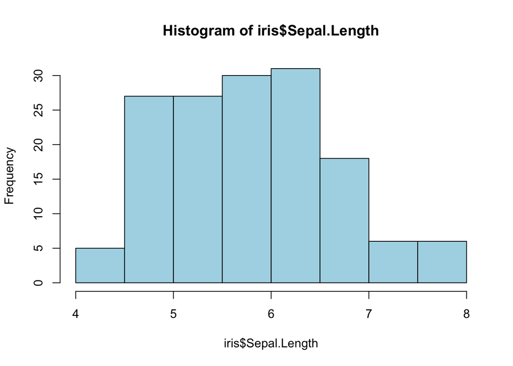

```r
hist_info <- hist(iris$Sepal.Length, col = "lightblue")
```

히스토그램을 그리는 `hist()` 함수는 유용한 정보를 list로 반환한다. 정보의 반환을 `return()` 함수가 아닌 `invisible()` 함수를 사용해서 별도의 이름에 할당한 후 그 정보를 사용할 수 있다. 특히 계급을 정의할 수 있는 계급의 경계는 breaks로, 계급 구간에 포함된 원 데이터의 개수인 `도수(frequency)`는 counts로 반환되었다. density는 `상대도수(relative frequency)`를 의미한다.

```r
hist_info
```

```
## $breaks
## [1] 4.0 4.5 5.0 5.5 6.0 6.5 7.0 7.5 8.0
##
## $counts
## [1]  5 27 27 30 31 18  6  6
##
## $density
## [1] 0.06666667 0.36000000 0.36000000 0.40000000 0.41333333 0.24000000 0.08000000
## [8] 0.08000000
##
## $mids
## [1] 4.25 4.75 5.25 5.75 6.25 6.75 7.25 7.75
##
## $xname
## [1] "iris$Sepal.Length"
##
## $equidist
## [1] TRUE
##
## attr(,"class")
## [1] "histogram"
```

### cut() 함수로 비닝하기

R에서는 `cut()` 함수로 비닝한다. 그런데 사용자가 계급의 경계인 breaks를 지정해 주어야 한다. 앞에서 수행한 히스토그램의 정보를 활용해 보자.

```r
bins <- cut(iris$Sepal.Length, breaks = hist_info$breaks)

bins
```

```
##   [1] (5,5.5] (4.5,5] (4.5,5] (4.5,5] (4.5,5] (5,5.5] (4.5,5] (4.5,5] (4,4.5]
##  [10] (4.5,5] (5,5.5] (4.5,5] (4.5,5] (4,4.5] (5.5,6] (5.5,6] (5,5.5] (5,5.5]
##  [19] (5.5,6] (5,5.5] (5,5.5] (5,5.5] (4.5,5] (5,5.5] (4.5,5] (4.5,5] (4.5,5]
##  [28] (5,5.5] (5,5.5] (4.5,5] (4.5,5] (5,5.5] (5,5.5] (5,5.5] (4.5,5] (4.5,5]
##  [37] (5,5.5] (4.5,5] (4,4.5] (5,5.5] (4.5,5] (4,4.5] (4,4.5] (4.5,5] (5,5.5]
##  [46] (4.5,5] (5,5.5] (4.5,5] (5,5.5] (4.5,5] (6.5,7] (6,6.5] (6.5,7] (5,5.5]
##  [55] (6,6.5] (5.5,6] (6,6.5] (4.5,5] (6.5,7] (5,5.5] (4.5,5] (5.5,6] (5.5,6]
##  [64] (6,6.5] (5.5,6] (6.5,7] (5.5,6] (5.5,6] (6,6.5] (5.5,6] (5.5,6] (6,6.5]
##  [73] (6,6.5] (6,6.5] (6,6.5] (6.5,7] (6.5,7] (6.5,7] (5.5,6] (5.5,6] (5,5.5]
##  [82] (5,5.5] (5.5,6] (5.5,6] (5,5.5] (5.5,6] (6.5,7] (6,6.5] (5.5,6] (5,5.5]
##  [91] (5,5.5] (6,6.5] (5.5,6] (4.5,5] (5.5,6] (5.5,6] (5.5,6] (6,6.5] (5,5.5]
## [100] (5.5,6] (6,6.5] (5.5,6] (7,7.5] (6,6.5] (6,6.5] (7.5,8] (4.5,5] (7,7.5]
## [109] (6.5,7] (7,7.5] (6,6.5] (6,6.5] (6.5,7] (5.5,6] (5.5,6] (6,6.5] (6,6.5]
## [118] (7.5,8] (7.5,8] (5.5,6] (6.5,7] (5.5,6] (7.5,8] (6,6.5] (6.5,7] (7,7.5]
## [127] (6,6.5] (6,6.5] (6,6.5] (7,7.5] (7,7.5] (7.5,8] (6,6.5] (6,6.5] (6,6.5]
## [136] (7.5,8] (6,6.5] (6,6.5] (5.5,6] (6.5,7] (6.5,7] (6.5,7] (5.5,6] (6.5,7]
## [145] (6.5,7] (6.5,7] (6,6.5] (6,6.5] (6,6.5] (5.5,6]
## Levels: (4,4.5] (4.5,5] (5,5.5] (5.5,6] (6,6.5] (6.5,7] (7,7.5] (7.5,8]
```

```r
table(bins)
```

```
## bins
## (4,4.5] (4.5,5] (5,5.5] (5.5,6] (6,6.5] (6.5,7] (7,7.5] (7.5,8]
##       5      27      27      30      31      18       6       6
```

`pretty()` 함수는 적당하게 계급의 경계를 구해준다. 이 함수를 이용해서 비닝해 보자.

```r
pretty(iris$Sepal.Length)
```

```
## [1] 4 5 6 7 8
```

```r
cut(iris$Sepal.Length, breaks = pretty(iris$Sepal.Length))
```

```
##   [1] (5,6] (4,5] (4,5] (4,5] (4,5] (5,6] (4,5] (4,5] (4,5] (4,5] (5,6] (4,5]
##  [13] (4,5] (4,5] (5,6] (5,6] (5,6] (5,6] (5,6] (5,6] (5,6] (5,6] (4,5] (5,6]
##  [25] (4,5] (4,5] (4,5] (5,6] (5,6] (4,5] (4,5] (5,6] (5,6] (5,6] (4,5] (4,5]
##  [37] (5,6] (4,5] (4,5] (5,6] (4,5] (4,5] (4,5] (4,5] (5,6] (4,5] (5,6] (4,5]
##  [49] (5,6] (4,5] (6,7] (6,7] (6,7] (5,6] (6,7] (5,6] (6,7] (4,5] (6,7] (5,6]
##  [61] (4,5] (5,6] (5,6] (6,7] (5,6] (6,7] (5,6] (5,6] (6,7] (5,6] (5,6] (6,7]
##  [73] (6,7] (6,7] (6,7] (6,7] (6,7] (6,7] (5,6] (5,6] (5,6] (5,6] (5,6] (5,6]
##  [85] (5,6] (5,6] (6,7] (6,7] (5,6] (5,6] (5,6] (6,7] (5,6] (4,5] (5,6] (5,6]
##  [97] (5,6] (6,7] (5,6] (5,6] (6,7] (5,6] (7,8] (6,7] (6,7] (7,8] (4,5] (7,8]
## [109] (6,7] (7,8] (6,7] (6,7] (6,7] (5,6] (5,6] (6,7] (6,7] (7,8] (7,8] (5,6]
## [121] (6,7] (5,6] (7,8] (6,7] (6,7] (7,8] (6,7] (6,7] (6,7] (7,8] (7,8] (7,8]
## [133] (6,7] (6,7] (6,7] (7,8] (6,7] (6,7] (5,6] (6,7] (6,7] (6,7] (5,6] (6,7]
## [145] (6,7] (6,7] (6,7] (6,7] (6,7] (5,6]
## Levels: (4,5] (5,6] (6,7] (7,8]
```

## dlookr을 이용한 비닝

### 예제 데이터 생성

`ISLR` 패키지의 `Carseats`는 유아용 차량 시트 판매에 대한 정보를 담고 있다. 400개의 관측치로 11개의 변수를 가지고 있다.

`Income`은 소득 수준을 나타내며, 그 단위는 1000 US 달러다.

```r
# Generate data for the example
carseats <- ISLR::Carseats

dim(carseats)
```

```
## [1] 400  11
```

```r
names(carseats)
```

```
##  [1] "Sales"       "CompPrice"   "Income"      "Advertising" "Population"
##  [6] "Price"       "ShelveLoc"   "Age"         "Education"   "Urban"
## [11] "US"
```

```r
carseats[sample(seq(NROW(carseats)), 20), "Income"] <- NA
carseats[sample(seq(NROW(carseats)), 5), "Urban"] <- NA

carseats$Income
```

```
##   [1]  73  48  35 100  64 113 105  81 110 113  78  94  35  28 117  95  NA  74
##  [19] 110  76  NA  29  46  31 119  32 115 118  74  99  94  58  NA  38  54  84
##  [37]  76  41  NA  60  98  53  69  42  79  NA  90  98  52  93  32  90  40  64
##  [55] 103  81  82  91  93  71 102  32  45  88  67  26  92  61  69  59  NA  NA
##  [73]  45  NA  68 111  87  71  48  67 100  72  83  36  25 103  84  67  42  66
##  [91]  22  46 113  30  97  25  42  82  77  47  69  93  22  91  96 100  33 107
## [109]  79  65  62 118  99  29  87  35  75  53  88  94 105  89 100 103 113  78
## [127]  68  48 100 120  84  69  NA  98  NA  94  75  NA 103  62  60  42  84  88
## [145]  68  63  83  54 119 120  84  58  78  36  69  72  34  58  90  60  28  21
## [163]  74  64  64  58  67  73  89  41  39 106 102  91  24  89 107  72  71  25
## [181]  NA  83  60  74  33 100  51  32  37  NA  37  42  26  70  98  93  28  61
## [199]  80  88  92  83  78  82  80  22  67 105  54  21  41 118  69  84 115  83
## [217]  33  44  61  79 120  44 119  45  82  25  33  64  73 104  60  69  80  76
## [235]  62  32  34  28  24 105  80  63  46  25  30  43  56 114  52  67 105 111
## [253]  97  24 104  81  40  62  38  36 117  NA  77  26  29  35  93  NA  57  69
## [271]  26  56  33 106  93 119  69  48 113  57  86  69  96 110  46  NA 118  44
## [289]  40  77 111  70  66  84  76  35  44  83  63  40  78  93  77  52  98  29
## [307]  32  92  80 111  65  68 117  81  33  21  36  30  72  45  70  39  50 105
## [325]  65  69  30  38  66  54  59  63  33  60 117  70  NA  38  24  44  29 120
## [343] 102  NA  80  68  NA  39 102  27 101 115 103  67  NA 100 109  73  96  62
## [361]  86  25  55  75  21  30  56 106  22 100  41  81  50  71  47  46  60  61
## [379]  88 111  64  65  28 117  37  73 116  73  89  42  75  63  42  51  58 108
## [397]  23  26  79  37
```

### 비닝하기

`dlookr` 패키지의 `binning()` 함수는 연속형 변수를 범주형 변수로 비닝한다. `Income`을 비닝해 보자. 소득이 10개 소득 구간의 범주로 비닝되었다.

```r
library(dlookr)

bin <- binning(carseats$Income)

bin
```

```
## binned type: quantile
## number of bins: 10
## x
##     [21,30]   (30,39.4] (39.4,50.4]   (50.4,62]     (62,69]     (69,77]
##          40          36          38          40          41          34
##   (77,85.1]   (85.1,97]    (97,107]   (107,120]        <NA>
##          37          39          38          37          20
```

`summary()` 함수는 범주화된 구간의 도수분포표(frequency table)를 구해준다.

```r
summary(bin)
```

```
##         levels freq   rate
## 1      [21,30]   40 0.1000
## 2    (30,39.4]   36 0.0900
## 3  (39.4,50.4]   38 0.0950
## 4    (50.4,62]   40 0.1000
## 5      (62,69]   41 0.1025
## 6      (69,77]   34 0.0850
## 7    (77,85.1]   37 0.0925
## 8    (85.1,97]   39 0.0975
## 9     (97,107]   38 0.0950
## 10   (107,120]   37 0.0925
## 11        <NA>   20 0.0500
```

`plot()` 함수는 범주화된 구간에 대한 분포를 시각화한다. 플롯 상단은 변형된 히스토그램이다. 일반적으로 히스토그램은 구간의 너비는 동일하고, 높이로 그 밀도를 가늠한다. 그러나 이 변형된 히스토그램은 구간의 너비가 실제 구간의 길이와 동일하게 표현된다. 그러므로 높이가 밀도를 의미하지 않는다. “밀도는 사각형의 너비 $\times$ 사각형의 높이다.” 즉, 기본 히스토그램보다 더 많은 정보를 표현한다.

기본에 우리가 알고 있는 히스토그램은 아래의 막대 그래프와 유사하다. 즉, 두 플롯을 이용해서 데이터의 분포를 좀 더 직관적으로 파악할 수 있는 시각화 도구다.

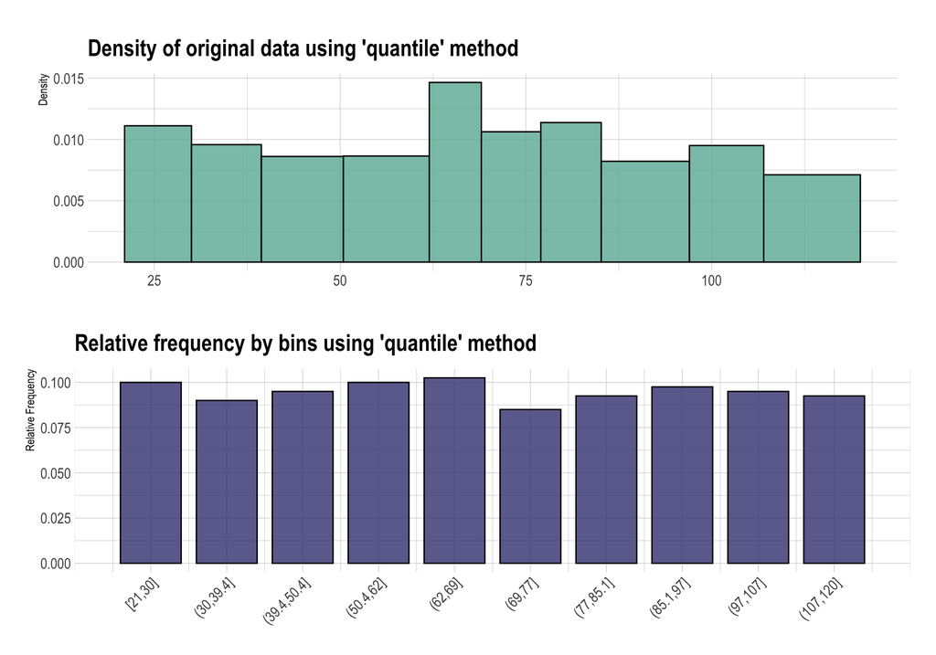

```r
plot(bin)
```

앞에서 소득을 소득 구간으로 비닝할 때 사용한 비닝 방법은 “quantile”이다. 이 방법은 분위수의 간격이 동일하게 구간을 나눈다. 그러므로 구간이 10개이므로 첫째 구간은 0~10% 분위수 구간이다. 즉, 10% 분위수는 30이다. 연산 과정에서 정확하게 딱 떨어지지는 않지만, 범주별로 동일한(거의) 도수를 갖게 된다.

이번에는 각 구간의 너비(interval)가 동일하게 비닝한다. 간단하게 `type` 인수값을 “equal”로 지정한다.

```r
bin_equal <- binning(carseats$Income, type = "equal")

bin_equal
```

```
## binned type: equal
## number of bins: 10
## x
##   [21,30.9] (30.9,40.8] (40.8,50.7] (50.7,60.6] (60.6,70.5] (70.5,80.4]
##          40          40          34          31          54          45
## (80.4,90.3]  (90.3,100]   (100,110]   (110,120]        <NA>
##          38          38          28          32          20
```

```r
summary(bin_equal)
```

```
##         levels freq   rate
## 1    [21,30.9]   40 0.1000
## 2  (30.9,40.8]   40 0.1000
## 3  (40.8,50.7]   34 0.0850
## 4  (50.7,60.6]   31 0.0775
## 5  (60.6,70.5]   54 0.1350
## 6  (70.5,80.4]   45 0.1125
## 7  (80.4,90.3]   38 0.0950
## 8   (90.3,100]   38 0.0950
## 9    (100,110]   28 0.0700
## 10   (110,120]   32 0.0800
## 11        <NA>   20 0.0500
```

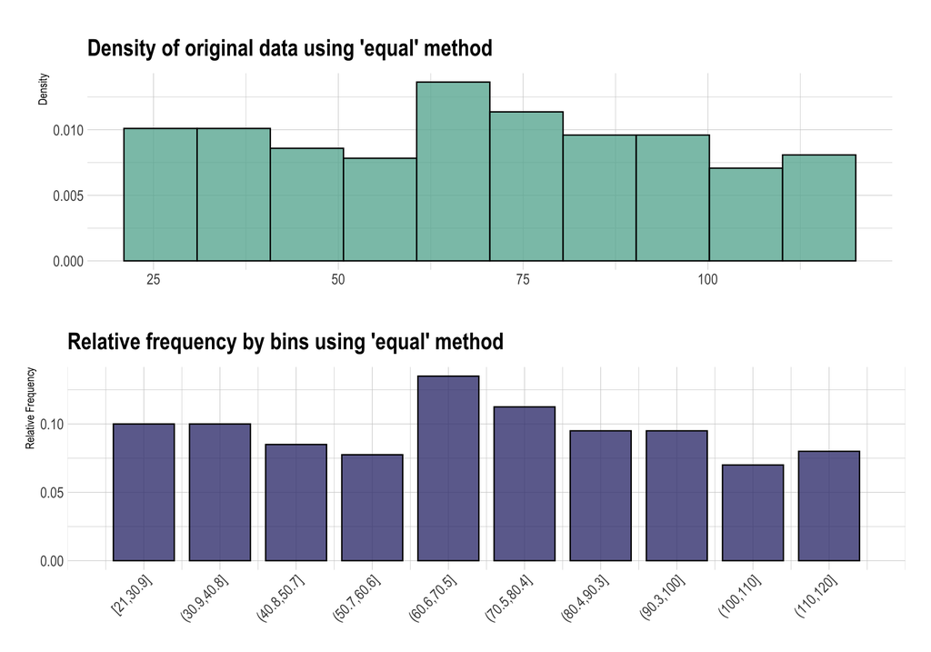

```r
plot(bin_equal)
```

이번에는 각 구간의 너비(interval)가 동일하게 비닝한다. 간단하게 `type` 인수값을 “equal”로 지정한다.

```r
bin_equal <- binning(carseats$Income, type = "equal")

bin_equal
```

```
## binned type: equal
## number of bins: 10
## x
##   [21,30.9] (30.9,40.8] (40.8,50.7] (50.7,60.6] (60.6,70.5] (70.5,80.4]
##          40          40          34          31          54          45
## (80.4,90.3]  (90.3,100]   (100,110]   (110,120]        <NA>
##          38          38          28          32          20
```

```r
summary(bin_equal)
```

```
##         levels freq   rate
## 1    [21,30.9]   40 0.1000
## 2  (30.9,40.8]   40 0.1000
## 3  (40.8,50.7]   34 0.0850
## 4  (50.7,60.6]   31 0.0775
## 5  (60.6,70.5]   54 0.1350
## 6  (70.5,80.4]   45 0.1125
## 7  (80.4,90.3]   38 0.0950
## 8   (90.3,100]   38 0.0950
## 9    (100,110]   28 0.0700
## 10   (110,120]   32 0.0800
## 11        <NA>   20 0.0500
```

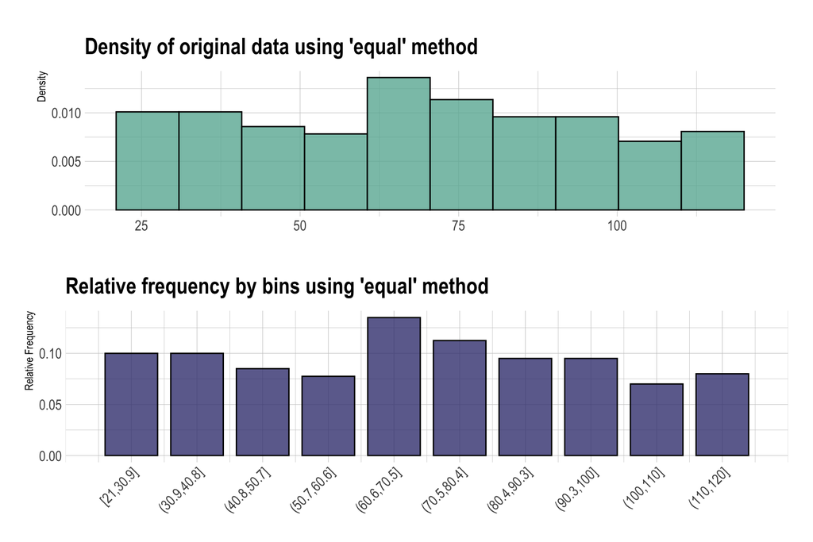

```r
plot(bin_equal)
```

이번에는 내부적으로 `base` 패키지의 `pretty()` 함수를 사용하는 “pretty” 방법이다. 간단하게 `type` 인수값을 “pretty”로 지정한다. 결과는 데이터에 따라 다르지만, 이번 데이터 사례는 “equal” 방법과 동일한 결과로 비닝한다.

```r
bin_pretty <- binning(carseats$Income, type = "pretty")

bin_pretty
```

```
## binned type: pretty
## number of bins: 10
## x
##   [20,30]   (30,40]   (40,50]   (50,60]   (60,70]   (70,80]   (80,90]  (90,100]
##        40        40        34        31        54        45        38        38
## (100,110] (110,120]      <NA>
##        28        32        20
```

```r
summary(bin_pretty)
```

```
##       levels freq   rate
## 1    [20,30]   40 0.1000
## 2    (30,40]   40 0.1000
## 3    (40,50]   34 0.0850
## 4    (50,60]   31 0.0775
## 5    (60,70]   54 0.1350
## 6    (70,80]   45 0.1125
## 7    (80,90]   38 0.0950
## 8   (90,100]   38 0.0950
## 9  (100,110]   28 0.0700
## 10 (110,120]   32 0.0800
## 11      <NA>   20 0.0500
```

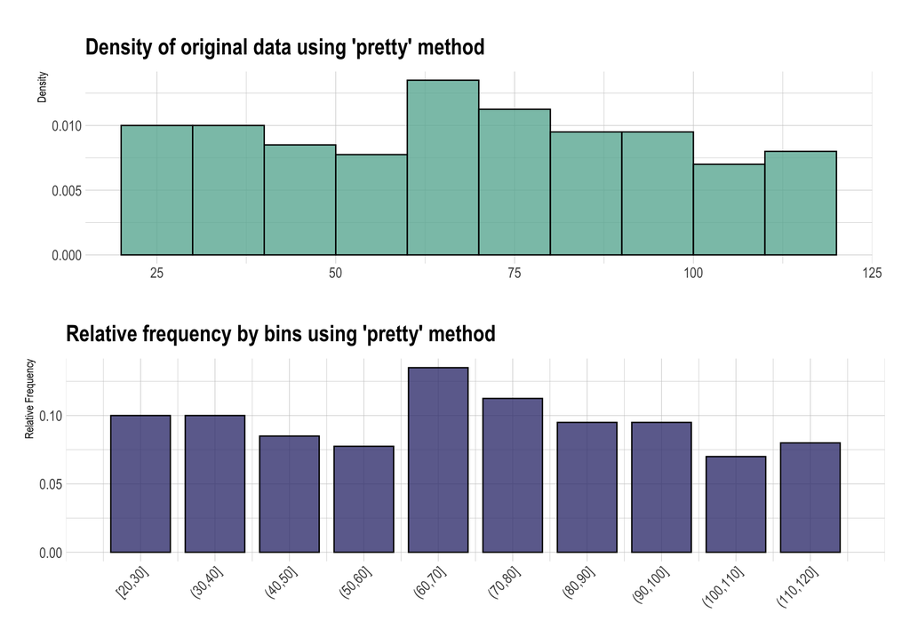

```r
plot(bin_pretty)
```

“kmenas” 방법은 `Kmeans 클러스터링` 기법을 이용해서 비닝한다. 하나의 연속형 변수로 `Kmeans 클러스터링` 후, 같은 클러스터에 포함된 값들을 하나의 구간으로 나눈다. 하나의 변수로 클러스터링하기 때문에 구간이 단조(monotonic, 주어진 순서를 보존하면서 상승/하강) 증가하게 형성된다.

```r
bin_kmeans <- binning(carseats$Income, type = "kmeans")

bin_kmeans
```

```
## binned type: kmeans
## number of bins: 10
## x
##   [21,29.5] (29.5,39.5] (39.5,52.5] (52.5,65.5] (65.5,75.5]   (75.5,85]
##          35          41          43          50          52          45
##   (85,96.5]  (96.5,106]   (106,114]   (114,120]        <NA>
##          37          38          18          21          20
```

```r
summary(bin_kmeans)
```

```
##         levels freq   rate
## 1    [21,29.5]   35 0.0875
## 2  (29.5,39.5]   41 0.1025
## 3  (39.5,52.5]   43 0.1075
## 4  (52.5,65.5]   50 0.1250
## 5  (65.5,75.5]   52 0.1300
## 6    (75.5,85]   45 0.1125
## 7    (85,96.5]   37 0.0925
## 8   (96.5,106]   38 0.0950
## 9    (106,114]   18 0.0450
## 10   (114,120]   21 0.0525
## 11        <NA>   20 0.0500
```

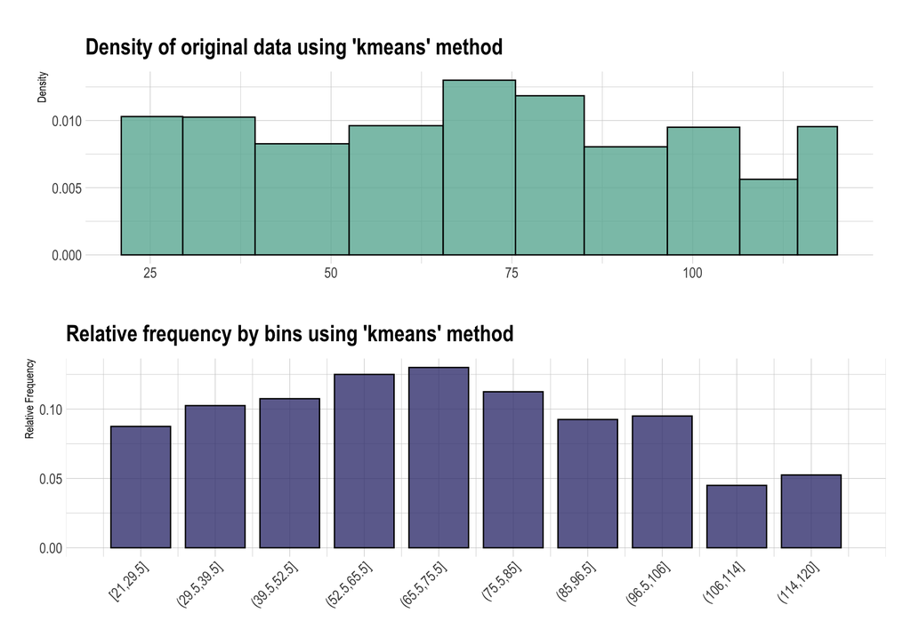

```r
plot(bin_kmeans)
```

`type` 인수값을 “bclust”로 지정하면 bagged clustering을 수행하여 비닝한다.

```r
bin_bclust <- binning(carseats$Income, type = "bclust")

bin_bclust
```

```
## binned type: bclust
## number of bins: 10
## x
##   [21,26.5] (26.5,34.5]   (34.5,49]   (49,58.5] (58.5,71.5] (71.5,78.5]
##          24          32          56          24          67          31
##   (78.5,85]   (85,95.5]  (95.5,106]   (106,120]        <NA>
##          32          34          41          39          20
```

```r
summary(bin_bclust)
```

```
##         levels freq   rate
## 1    [21,26.5]   24 0.0600
## 2  (26.5,34.5]   32 0.0800
## 3    (34.5,49]   56 0.1400
## 4    (49,58.5]   24 0.0600
## 5  (58.5,71.5]   67 0.1675
## 6  (71.5,78.5]   31 0.0775
## 7    (78.5,85]   32 0.0800
## 8    (85,95.5]   34 0.0850
## 9   (95.5,106]   41 0.1025
## 10   (106,120]   39 0.0975
## 11        <NA>   20 0.0500
```

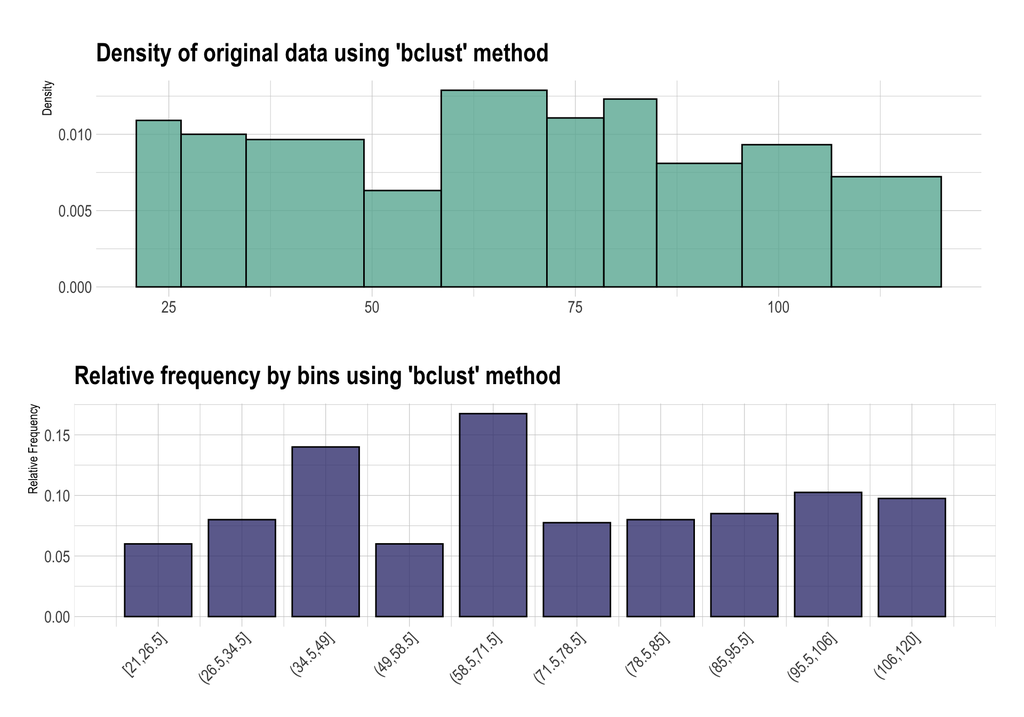

```r
plot(bin_bclust)
```

### 비닝 결과의 추출

비닝한 결과를 서머리하거나 시각화한 후 비닝한 결과에 확신이 생긴다면, `extract()` 함수로 비닝한 데이터를 추출한다. 마지막 예제, bagged clustering 기법의 비닝 결과를 채택하였다고 가정한다.

```r
carseats$Income_bin <- extract(bin_bclust)
```

```r
head(carseats$Income_bin, n = 10)
```

```
##  [1] (71.5,78.5] (34.5,49]   (34.5,49]   (95.5,106]  (58.5,71.5] (106,120]
##  [7] (95.5,106]  (78.5,85]   (106,120]   (106,120]
## 10 Levels: [21,26.5] < (26.5,34.5] < (34.5,49] < (49,58.5] < ... < (106,120]
```

### dplyr 패키지와의 협업

dlookr 패키지는 dplyr 패키지와 궁합이 잘 맞는다. 다음은 `Income`을 비닝 후 `ShelveLoc` 변수의 수준(levels)별로 비닝 구간의 분포를 비교한다.

```r
library(dplyr)

carseats %>%
 mutate(Income_bin = binning(carseats$Income) %>%
                     extract()) %>%
 group_by(ShelveLoc, Income_bin) %>%
 summarise(freq = n()) %>%
 arrange(ShelveLoc, desc(freq))
```

```
## # A tibble: 33 x 3
## # Groups:   ShelveLoc [3]
##    ShelveLoc Income_bin   freq
##    <fct>     <ord>       <int>
##  1 Bad       (50.4,62]      13
##  2 Bad       (85.1,97]      12
##  3 Bad       (107,120]      11
##  4 Bad       (77,85.1]      10
##  5 Bad       (39.4,50.4]     9
##  6 Bad       (62,69]         9
##  7 Bad       (97,107]        9
##  8 Bad       [21,30]         6
##  9 Bad       (30,39.4]       6
## 10 Bad       (69,77]         6
## # … with 23 more rows
```

`dlookr` 패키지의 `target_by()`, `relate()`, `plot.relate()` 함수를 이용하면, dplyr 구문 형태로 쉽게 그 분포를 시각화 할 수 있다.

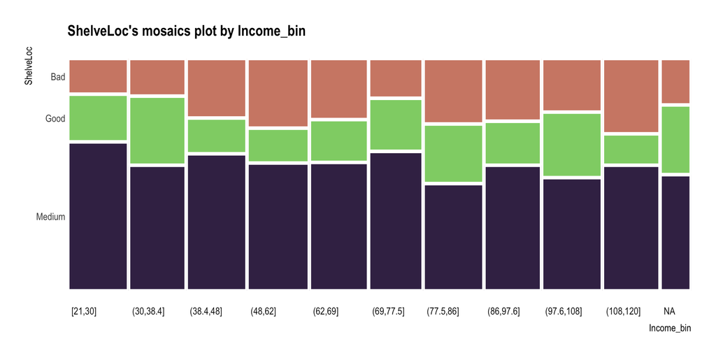

```r
carseats %>%
  mutate(Income_bin = binning(carseats$Income) %>%
           extract()) %>%
  target_by(ShelveLoc) %>%
  relate(Income_bin) %>%
  plot()
```

### 그 밖의 기능

`binning()` 함수는 비닝 결과를 조정하는 여러 인수를 지원한다. 하나씩 살펴보자.

#### Bins 개수 지정하기

```r
bin_bclust <- binning(carseats$Income, type = "bclust", nbins = 5)

bin_bclust
```

```
## binned type: bclust
## number of bins: 5
## x
##   [21,51.5] (51.5,75.5]   (75.5,85]    (85,108]   (108,120]        <NA>
##         116         105          45          78          36          20
```

```r
summary(bin_bclust)
```

```
##        levels freq   rate
## 1   [21,51.5]  116 0.2900
## 2 (51.5,75.5]  105 0.2625
## 3   (75.5,85]   45 0.1125
## 4    (85,108]   78 0.1950
## 5   (108,120]   36 0.0900
## 6        <NA>   20 0.0500
```

[figure not shown]

```r
plot(bin_bclust)
```

#### ordered factor 또는 factor

`binning()` 함수로 만들어진 범주는 R의 `ordered factor`로 반환된다. 만약 분석가가 `ordered factor`가 아닌 `factor`를 원한다면 `ordered` 인수값에 FALSE를 지정한다. 기본값은 TRUE이기 때문에 앞에서 수행한 모든 예제는 순서 범주형인 `ordered factor`로 반환되었다.

```r
bin_bclust <- binning(carseats$Income, type = "bclust")

extract(bin_bclust) %>%
  head()
```

```
## [1] (65.5,78.5] (40.5,50.5] (26.5,40.5] (93.5,110]  (54.5,65.5] (110,120]
## 10 Levels: [21,26.5] < (26.5,40.5] < (40.5,50.5] < ... < (110,120]
```

```r
bin_bclust <- binning(carseats$Income, type = "bclust", ordered = FALSE)

extract(bin_bclust) %>%
  head()
```

```
## [1] (65.5,76.5] (41.5,49]   (27.5,41.5] (97.5,106]  (55.5,65.5] (106,120]
## 10 Levels: [21,27.5] (27.5,41.5] (41.5,49] (49,55.5] ... (106,120]
```

#### 범주 라벨 지정하기

범주 라벨 이름을 breaks를 이용해서 (34.5,49]와 같이 표현할 수도 았지만, 분석가가 `labels` 인수를 사용해서 다음처럼 의미를 부여할 수도 있다.

```r
bin <- binning(carseats$Income, nbins = 3, labels = c("Low", "Middle", "High"))
bin
```

```
## binned type: quantile
## number of bins: 3
## x
##    Low Middle   High   <NA>
##    129    124    127     20
```

```r
summary(bin)
```

```
##   levels freq   rate
## 1    Low  129 0.3225
## 2 Middle  124 0.3100
## 3   High  127 0.3175
## 4   <NA>   20 0.0500
```

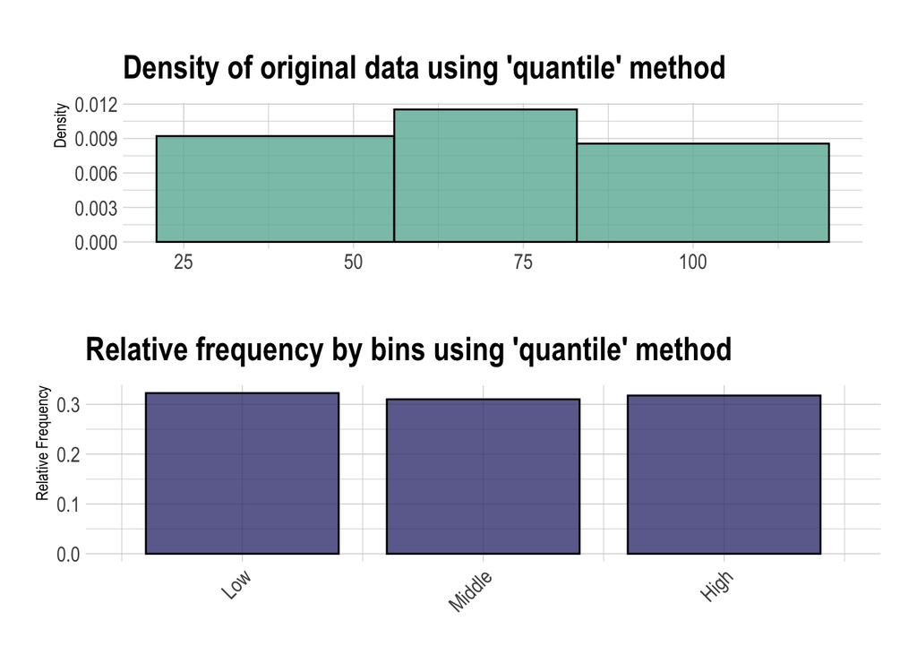

```r
plot(bin)
```

#### Breaks를 이쁘게 다듬기

연속형 변수에서 breaks는 일반적으로 소수점으로 만들어진다. 이 경우에는 개별 breaks의 소수점 아래 자리수가 다를 수 있다. 다른 자리수로 만든 범주는 시각적으로 해석하기에 거추장스럽다. 이 경우에는 `approxy.lab` 인수를 TRUE로 지정하면 깔끔한 형태로 바꿔준다. 기본값이 TRUE이기 때문에 별도로 지정하지 않아도 된다.

```r
bin <- binning(carseats$Income, type = "bclust", approxy.lab = FALSE)
bin
```

```
## binned type: bclust
## number of bins: 10
## x
##    [21,32.5]  (32.5,42.5]    (42.5,49]    (49,57.5]    (57.5,65]    (65,78.5]
##           47           44           21           19           38           65
##    (78.5,85]    (85,95.5] (95.5,107.5]  (107.5,120]         <NA>
##           32           34           43           37           20
```

```r
bin <- binning(carseats$Income, type = "bclust", approxy.lab = TRUE)
bin
```

```
## binned type: bclust
## number of bins: 10
## x
##   [21,27.5] (27.5,39.5]   (39.5,49]     (49,56]   (56,66.5] (66.5,72.5]
##          25          51          36          17          43          35
## (72.5,86.5] (86.5,96.5]  (96.5,108]   (108,120]        <NA>
##          61          35          41          36          20
```